# Coding Assignment 1

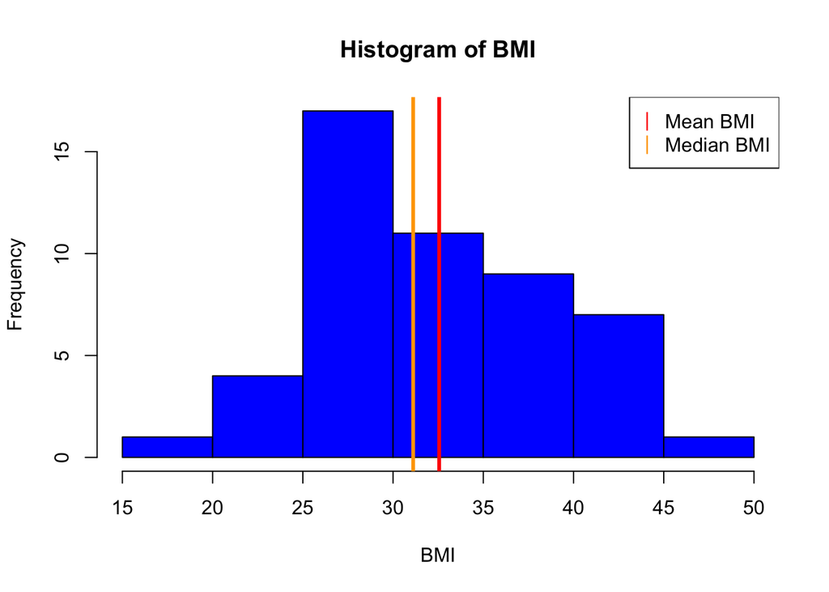

```r
hist(Health1$BMI,  xlab = "BMI", ylab = "Frequency",main = "Histogram of BMI", col = "blue")
abline(v = mean(Health1$BMI),                       # Add line for mean
       col = "red",
       lwd = 3)
abline(v = median(Health1$BMI),                       # Add line for median
       col = "orange",
       lwd = 3)
legend("topright",legend = c("Mean BMI","Median BMI"),pch = "|", col=c("red", "orange",lwd=2))
```

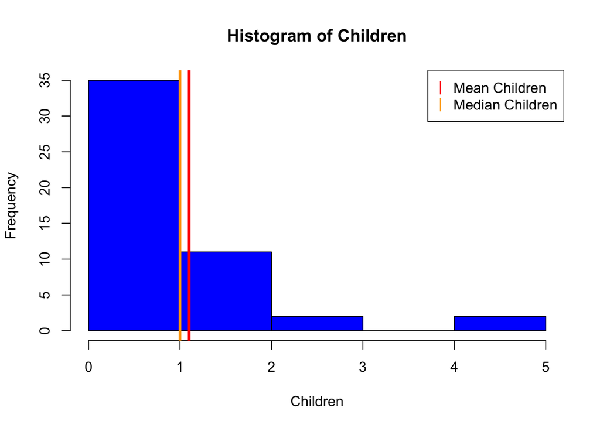

```r
hist(Health1$Children, xlab = "Children", ylab = "Frequency",main = "Histogram of Children", col = "blue")
abline(v = mean(Health1$Children),                       # Add line for mean
       col = "red",
       lwd = 3)
abline(v = median(Health1$Children),                       # Add line for median
       col = "orange",
       lwd = 3)
legend("topright",legend = c("Mean Children","Median Children"),pch = "|", col=c("red", "orange",lwd=2))
```

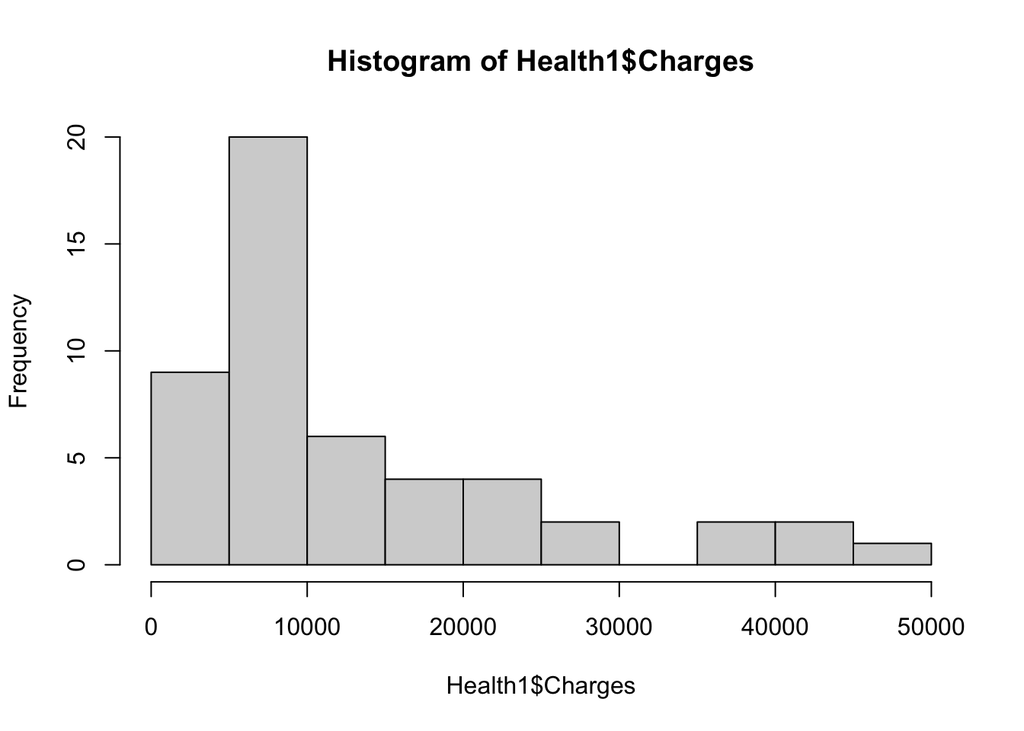

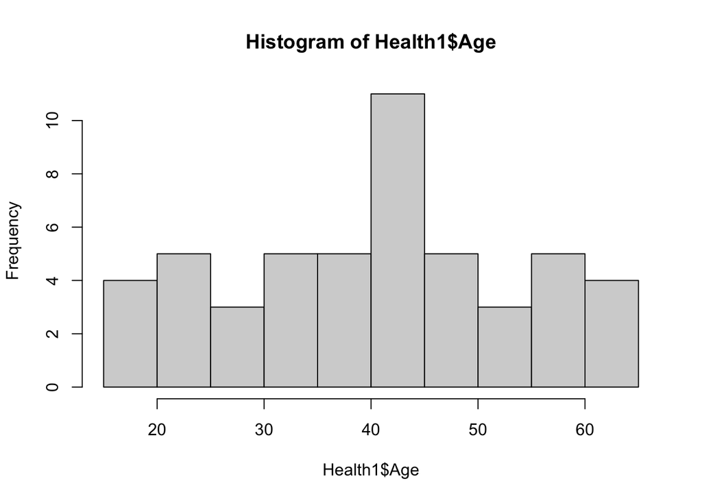

```r
hist(Health1$Age)
```

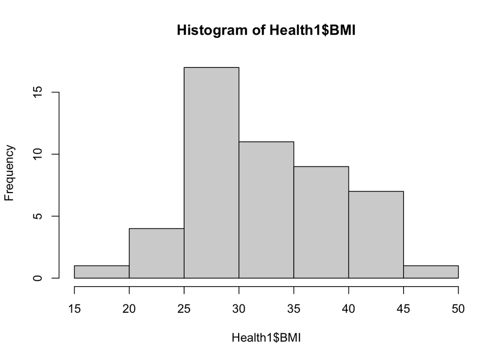

```r
hist(Health1$BMI)
```

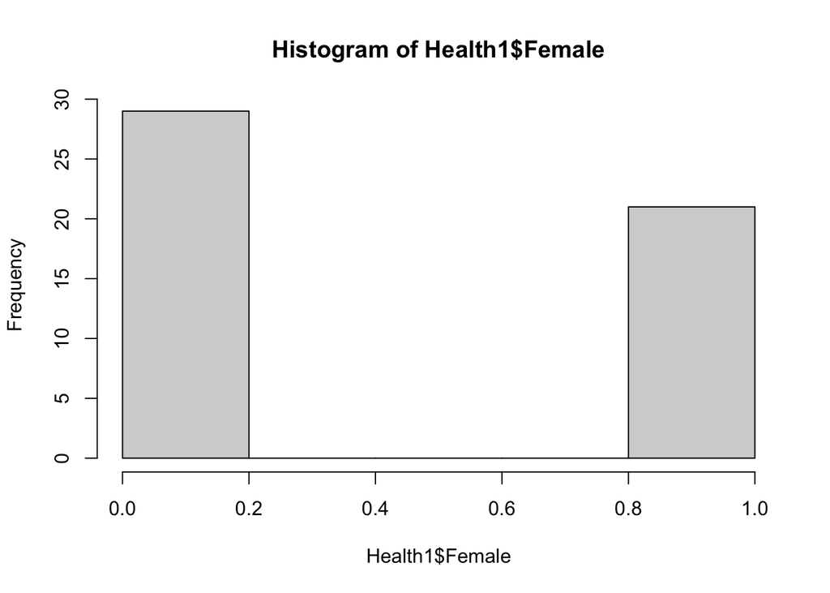

```r
hist(Health1$Female)
```

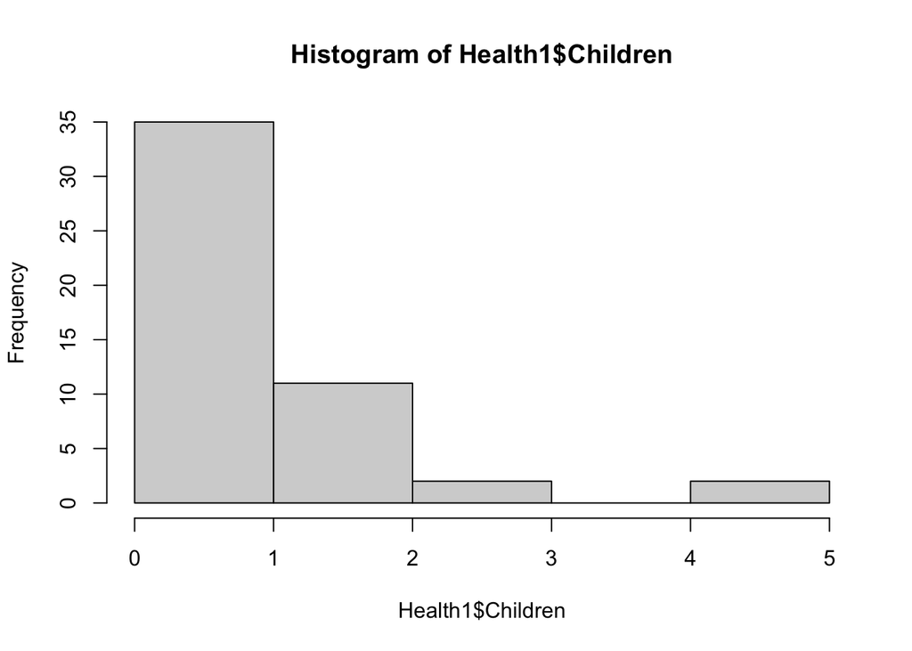

```r
hist(Health1$Children)
```

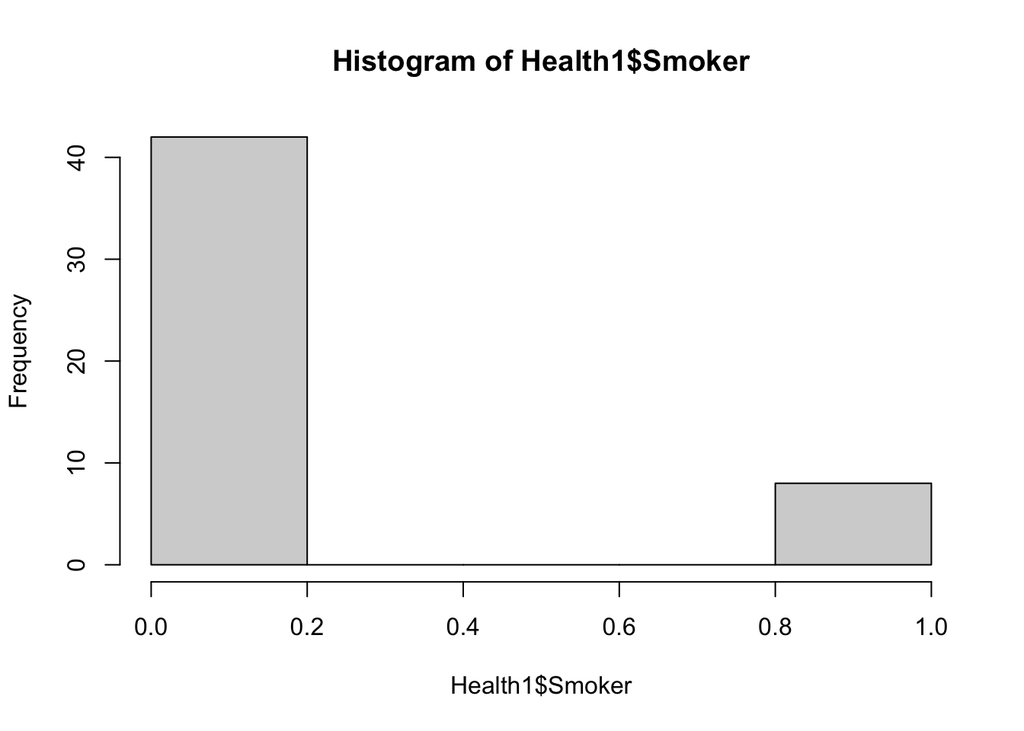

```r
hist(Health1$Smoker)
```

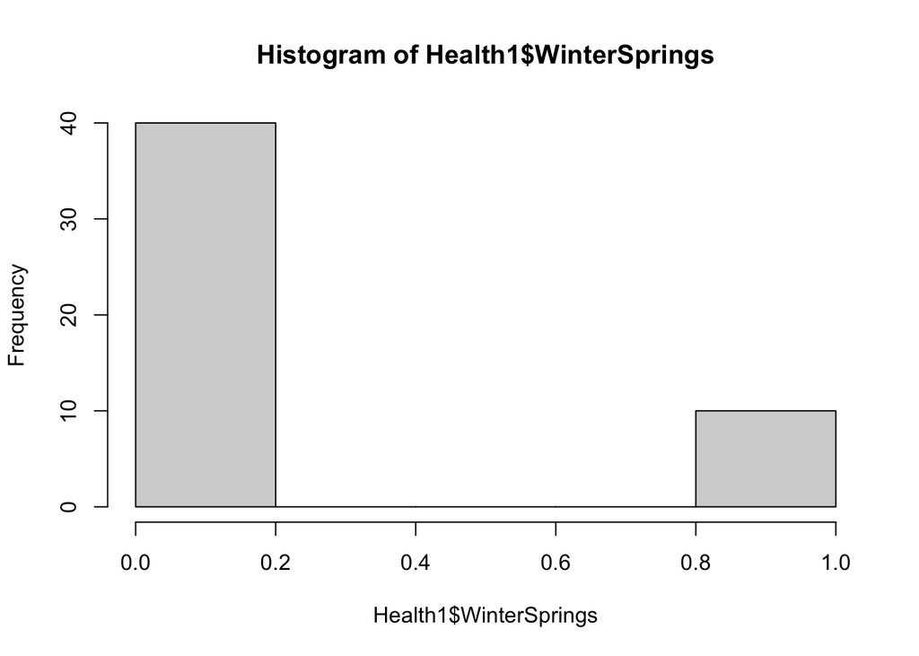

```r
hist(Health1$WinterSprings)
```

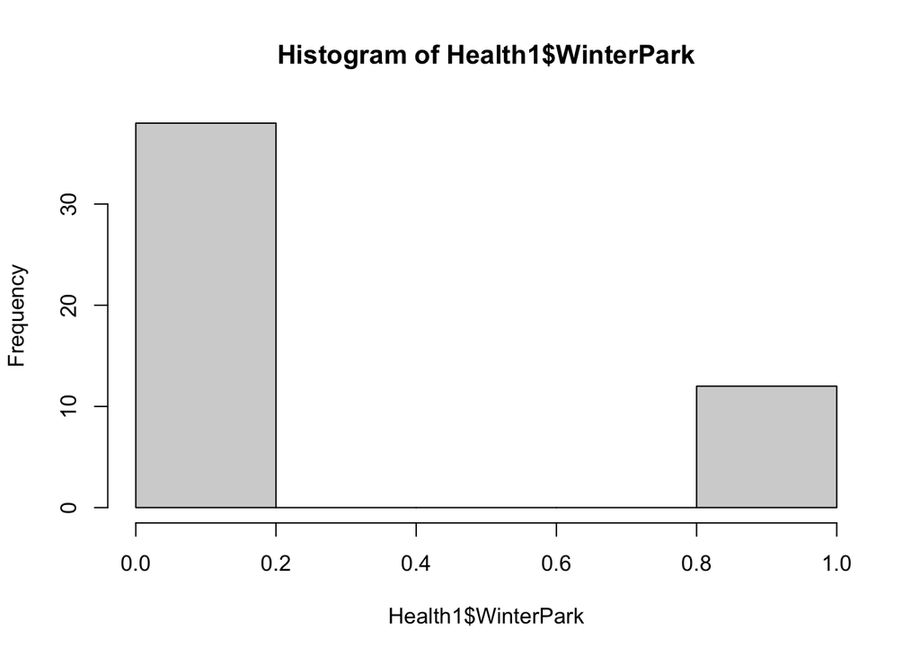

```r
hist(Health1$WinterPark)
```

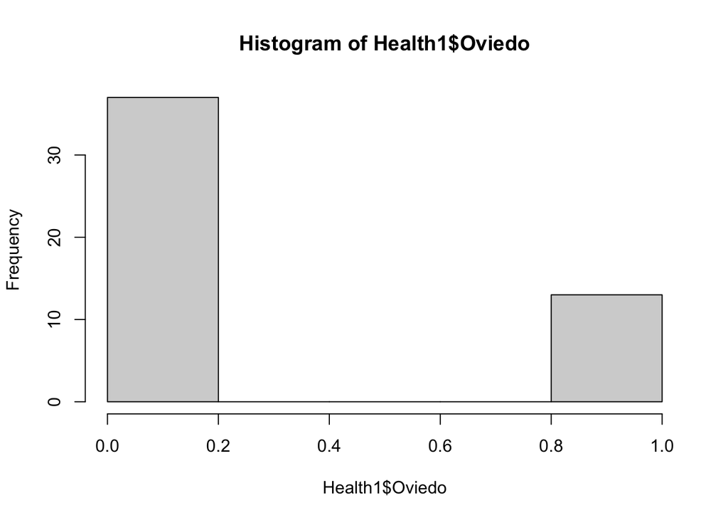

```r
hist(Health1$Oviedo)
```

```r
#Spread

## variance

var(Health1$Charges,na.rm = TRUE)
```

```
## [1] 129892851
```

```r
var(Health1$Age,na.rm = TRUE)
```

```
## [1] 165.0078
```

```r
var(Health1$BMI,na.rm = TRUE)
```

```
## [1] 39.56672
```

```r
var(Health1$Children,na.rm = TRUE)
```

```
## [1] 1.397959
```

```r
## standard deviation

sd(Health1$Charges,na.rm = TRUE)
```

```
## [1] 11397.05
```

```r
sd(Health1$Age,na.rm = TRUE)
```

```
## [1] 12.84553
```

```r
sd(Health1$BMI,na.rm = TRUE)
```

```
## [1] 6.290208
```

```r
sd(Health1$Children,na.rm = TRUE)
```

```
## [1] 1.182353
```

```r
## IQR

IQR(Health1$Charges,na.rm = TRUE)
```

```
## [1] 11303.03
```

```r
IQR(Health1$Age,na.rm = TRUE)
```

```
## [1] 16.75
```

```r
IQR(Health1$BMI,na.rm = TRUE)
```

```
## [1] 8.17625
```

```r
IQR(Health1$Children,na.rm = TRUE)
```

```
## [1] 2
```

```r
## range

range(Health1$Charges,na.rm = TRUE)
```

```
## [1]  1639.563 47403.880
```

```r
range(Health1$Age,na.rm = TRUE)
```

```
## [1] 19 63
```

```r
range(Health1$BMI,na.rm = TRUE)
```

```
## [1] 18.335 49.060
```

```r
range(Health1$Children,na.rm = TRUE)
```

```
## [1] 0 5
```

```r
##mode

getModes <- function(x) {
ux <- unique(x)
tab <- tabulate(match(x, ux))
ux[tab == max(tab)]
}
getModes(Health1$Charges)
```

```
##  [1]  1639.563 21232.182  6250.435 38282.749  4337.735  8968.330 12797.210
##  [8]  1984.453 17878.901  8930.935  9991.038  4527.183 15555.189  2690.114
## [15] 20462.998  2639.043  7358.176  6457.843 11381.325 28340.189 21098.554
## [22] 38344.566  2866.091 13063.883 11735.879  1981.582  5031.270  9447.250
## [29] 17560.380  6238.298 47403.880 11356.661  9724.530  3579.829  6653.789
## [36]  5472.449  7147.473  7640.309 20709.020 40974.165  7371.772 17496.306
## [43]  8027.968 28287.898 40273.645  5846.918 12982.875  9222.403  6610.110
## [50]  6710.192
```

```r
getModes(Health1$Age)
```

```
## [1] 48 41
```

```r
getModes(Health1$BMI)
```

```
## [1] 35.750 30.200 41.325 27.645
```

```r
getModes(Health1$Children)
```

```
## [1] 0
```

`I liked the addition of the mean and median lines (+1)`

# Question 2

Perform bivariate analyses on the quantitative variables (direction, strength and form). Describe the linear association between all variables.

**Bivariate Analysis of Charges & Age**

**Bivariate Analysis of Charges & BMI**

**Bivariate Analysis of Charges & Children**

**Bivariate Analysis of BMI & Age**

**Bivariate Analysis of BMI & Children**

This scatterplot shows a weak negative with no linear association between primary beneficiary and number of children covered by health insurance plan and primary beneficiary’s body mass index.

**Bivariate Analysis of Age & Children**

This scatterplot shows a weak negative with no linear association between age of the primary beneficiary and number of children covered by health insurance plan.

```
## [1] 0.3045961
```

[figure not shown]

```
## [1] 0.2246895
```

[figure not shown]

```
## [1] -0.04641818
```

[figure not shown]

```
## [1] 0.2192622
```

[figure not shown]

```
## [1] -0.01766343
```

[figure not shown]

```
## [1] -0.04178928
```

[figure not shown]

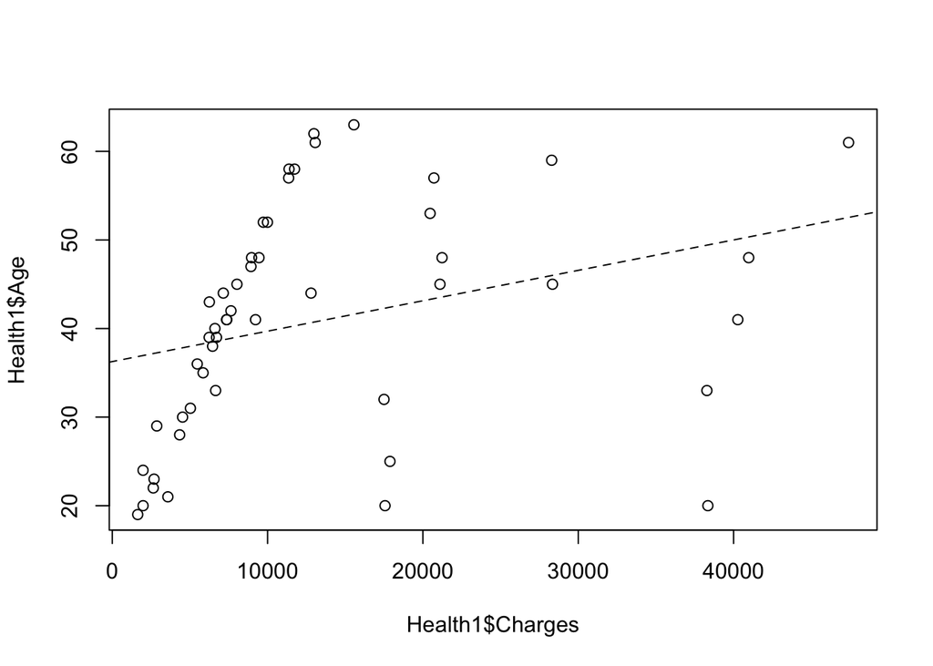

```
## [1] 0.2246895
```

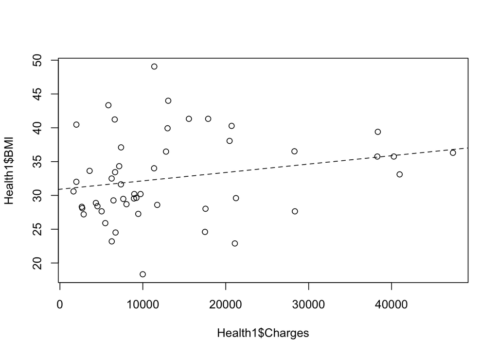

```
## [1] -0.05582743
```

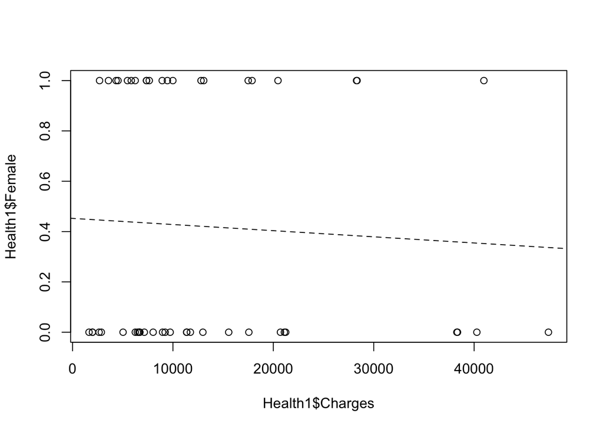

```
## [1] -0.04641818
```

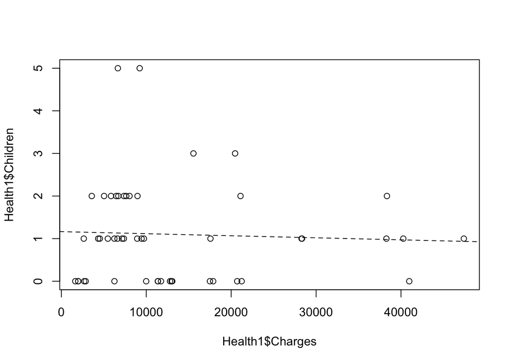

```
## [1] 0.7515227
```

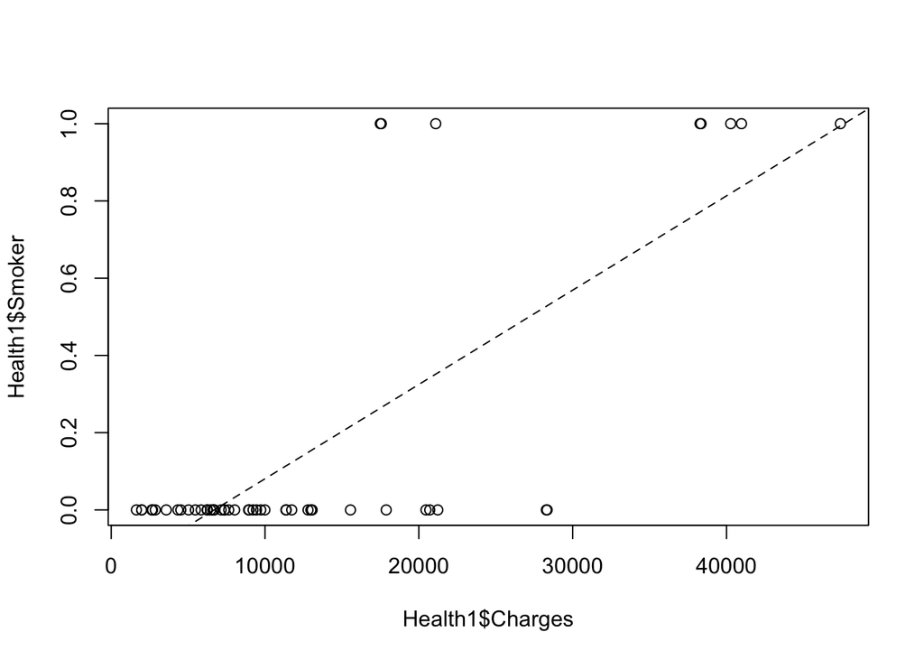

```
## [1] -0.1645759
```

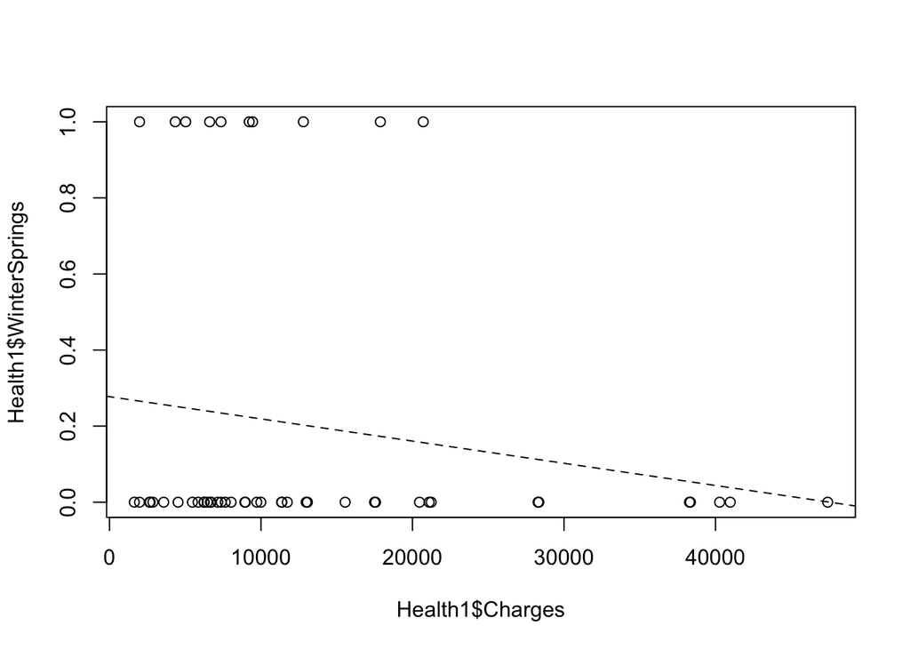

```
## [1] 0.2610734
```

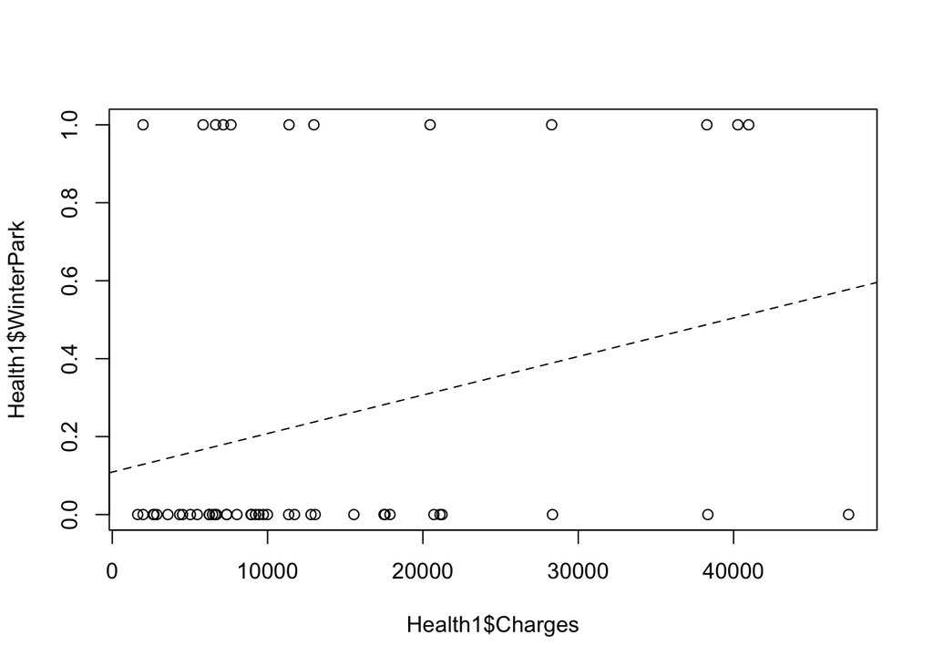

```
## [1] 0.08160874
```

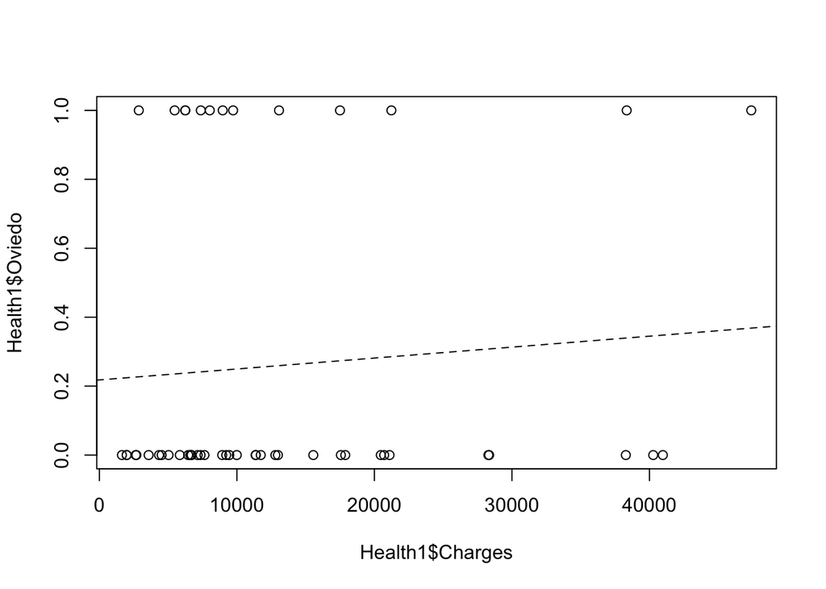

# Question 3

Generate a regression equation in the following form:

$$Charges =
\beta_{0}+\beta_{1}*Age+\beta_{2}*BMI+\beta_{3}*Children$$

```r
ts_model <- lm(Charges ~ Age + BMI + Children, data = Health1)
summary(ts_model)
```

```
##
## Call:
## lm(formula = Charges ~ Age + BMI + Children, data = Health1)
##
## Residuals:
##    Min     1Q Median     3Q    Max
## -11234  -6071  -4791   2692  28251
##
## Coefficients:
##             Estimate Std. Error t value Pr(>|t|)
## (Intercept)  -5840.7     9105.8  -0.641   0.5244
## Age            236.8      125.9   1.882   0.0662 .
## BMI            300.0      256.9   1.168   0.2488
## Children      -311.7     1334.4  -0.234   0.8163
## ---
## Signif. codes:  0 '***' 0.001 '**' 0.01 '*' 0.05 '.' 0.1 ' ' 1
##
## Residual standard error: 11030 on 46 degrees of freedom
## Multiple R-squared:   0.12,  Adjusted R-squared:  0.06262
## F-statistic: 2.091 on 3 and 46 DF,  p-value: 0.1144
```

Based on the data provided, the regression equation is as follows:

Charges = -5841 + 237Age + 300BMI - 312Children

# Question 4

An eager insurance representative comes back with a potential client. The client is 40, their BMI is 30, and they have one dependent. Using the regression equation above, predict the amount of medical expenses associated with this policy. (Provide a 95% confidence interval as well)

```r
newPrediction <- data.frame(Age = 40 , BMI = 30 , Children = 1)
predict(ts_model,
newdata = newPrediction,
interval = "confidence",
level = .95)
```

```
##        fit      lwr      upr
## 1 12321.89 8913.548 15730.23
```

The result indicates that the insurance representative can expect the value in medical expenses to be about 12,321.89 and that they can be 95 percent confident that the true value lies somewhere between 8,913,55 and 15,730.23.